# EFBMC Example

Code locations for required R packages not on CRAN:

1. [impala](https://github.com/sandialabs/rImpala)
2. [mvBayes](https://github.com/sandialabs/mvBayesR)

For questions please contact

J. Derek Tucker  
Statistical Sciences - 5573  
jdtuck@sandia.gov  
505-284-8415

[figure not shown]

# Setup

First we need to import the required packages and make a useful function for the data

```r
library(impala)
library(mvBayes)
library(BASS)
library(fdasrvf)
library(bayesplot)
library(coda)
library(readr)
library(interp)
library(progress)

make_matrix <- function(df,rownames = NULL){
  my_matrix <-  as.matrix(df)
  if(!is.null(rownames))
    rownames(my_matrix) = rownames
  my_matrix
}

library(knitr)
knitr::opts_chunk$set(cache = TRUE, warning = FALSE,
                      message = FALSE, cache.lazy = FALSE)
```

# Data Pre-Processing

Next we load in the training data from the computer model and extract the simulation parameters. We will also set a path to save the results

```r
data_path = '/Users/jdtuck/Documents/Data/zbmc'
sim_time = read.table(file.path(data_path, 'PlatinumBMC_May2023', 'Vinet', 'build1','time.out'))
sim_time = c(sim_time$V1)

simulations = read_table(
  file.path(
    data_path,
    'PlatinumBMC_May2023',
    'Vinet',
    'build1',
    'lhs_10000bp_5500res.txt'
  )
)

last_elem = 12
a = c(3,4,5,6,7,8,9,10,11,12)
sim_variables = simulations[, a]
sim_variables = make_matrix(sim_variables)
p = ncol(sim_variables)

new_dir = file.path(data_path, 'PlatinumBMC_May2023', 'Vinet', 'impala_id_bass')
ifelse(!dir.exists(file.path(new_dir)),
       dir.create(file.path(new_dir)),
       "Directory Exists")
```

```
## [1] "Directory Exists"
```

```r
save_fn = file.path(new_dir, "platinum_exp_all")
```

Next we will load in the experiment we wish to calibrate

```r
names = read_table(file.path(
                  data_path,
                  'PlatinumBMC_May2023',
                  'Vinet',
                  'suite',
                  'VISARFileNames.txt'), col_names=FALSE)
exps = 1:4
nexp = length(exps)
exp = list()
cnt = 1
for (i in exps) {
  parts = strsplit(paste(names[i,]),"/")
  exp[[cnt]] = read_table(
    file.path(
      data_path,
      'PlatinumBMC_May2023',
      'Vinet',
      'suite',
      parts[[1]][1],
      parts[[1]][3]
    ), col_names=FALSE  )
  cnt = cnt + 1
}
```

# Elastic Functional Alignment

We will now align the computer model output to the experiment. We will need the aligned data `ftilde_train` and the shooting vectors `vv_train`. Additionally we will need the shooting vector for the experiment. In this case, since we are aligning to the experiment warping function will be identity ($\gamma_{id}$) and then the corresponding shooting vector `vv_obs`.

There is the option of the parameter `lambda` in `multiple_align_functions` that restricts the amount of alignment. In some cases we will set this to a small value (e.g., 0.01) to remove heteroskedacity from the warping functions.

```r
gam_sim_list = list()
vv_sim_list = list()
ftilde_sim_list = list()
gam_obs_list = list()
vv_obs_list = list()
ftilde_obs_list = list()
ftilde_sd = list()
vv_train_sd = list()
fsim_list = list()
f_exp_list = list()
warp_list = list()

pb <- progress_bar$new(
  format = "aligning [:bar] :percent eta: :eta",
  clear = FALSE,
  total = nexp,
  width = 60
)
cnt = 1
for (idx in exps) {
  M1 = 1 + (idx - 1) * 500
  N1 = idx * 500
  M = 300
  time_new = seq(sim_time[M1], sim_time[N1], length.out = M)
  f_sim = matrix(0, M, nrow(simulations))
  for (i in 1:nrow(simulations)) {
    tmp = as.numeric(simulations[i, (M1 + last_elem):(N1 + last_elem)])
    f_sim[, i] = aspline(sim_time[M1:N1], tmp, time_new)$y
  }

  fsim_list[[cnt]] = f_sim

  f_exp = aspline(exp[[cnt]]$X1, exp[[cnt]]$X2, time_new)$y
  for (r in 1:5){
    f_exp[2:(M-1)] = (f_exp[1:(M-2)]+2*f_exp[2:(M-1)] + f_exp[3:M])/4
  }
  f_exp_list[[cnt]] = f_exp

  # align the data
  tt = seq(0, 1, length.out = M)
  out = multiple_align_functions(
    f_sim,
    tt,
    f_exp,
    lambda = 0.001,
    parallel = TRUE,
    showplot = FALSE,
    verbose = FALSE
  )
  warp_list[[cnt]] = out
  gam_sim_list[[cnt]] = out$warping_functions
  vv_sim_list[[cnt]] = gam_to_v(out$warping_functions)
  ftilde_sim_list[[cnt]] = out$fn

  gam_obs_list[[cnt]] = seq(0, 1, length.out=M)
  vv_obs_list[[cnt]] = gam_to_v(gam_obs_list[[cnt]])
  ftilde_obs_list[[cnt]] = f_exp

  cnt = cnt + 1

  pb$tick()

}
```

We will now plot the alignment results. First is the aligned functions.

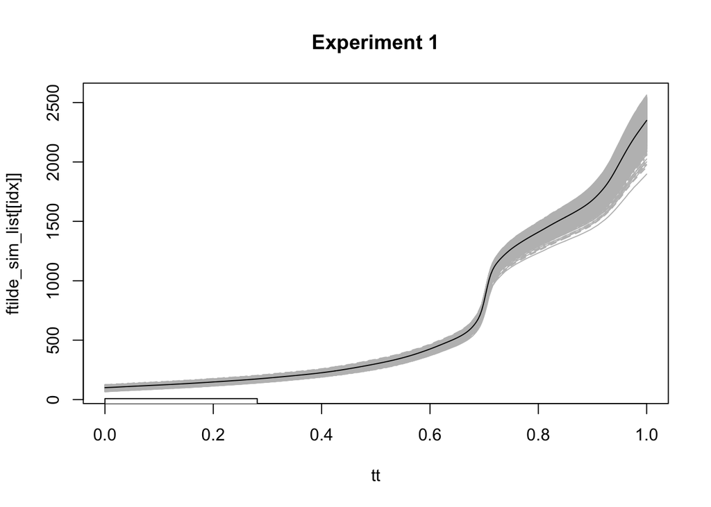

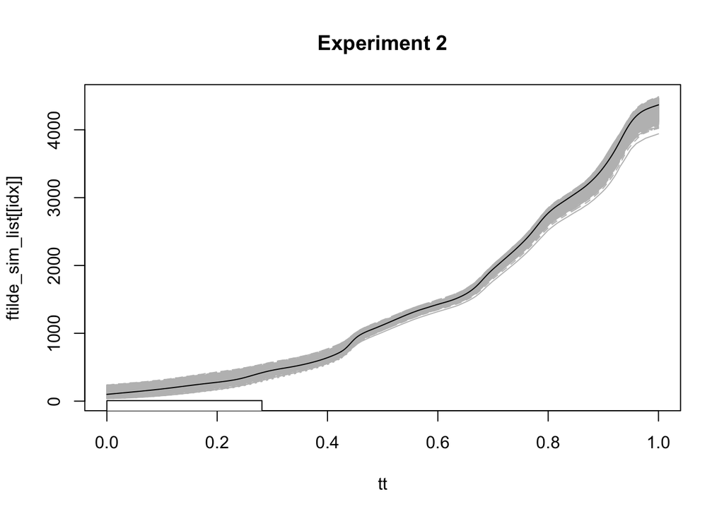

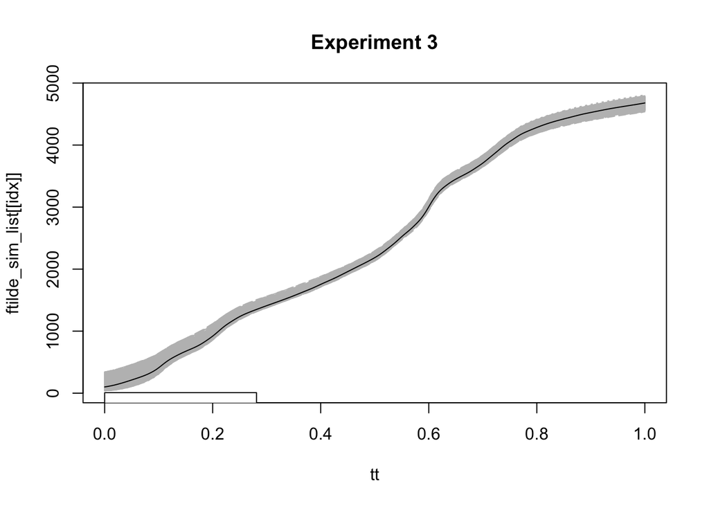

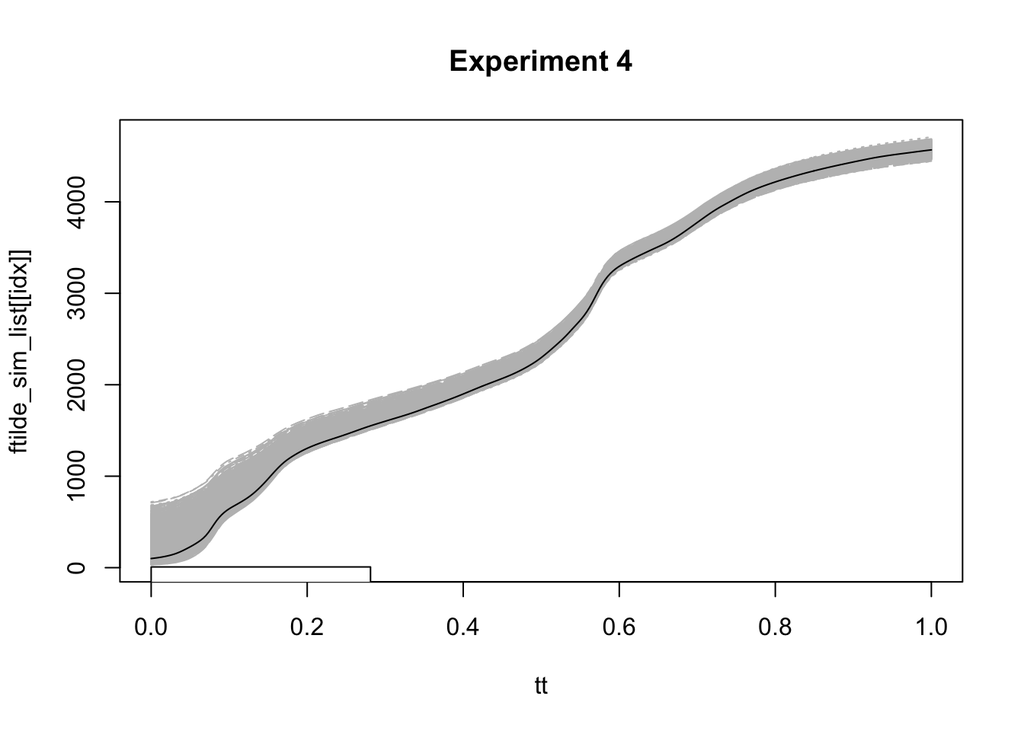

```r
for (idx in exps){
  matplot(tt, ftilde_sim_list[[idx]], type = "l", col = "gray", main=sprintf("Experiment %d",idx))
  lines(tt, ftilde_obs_list[[idx]], col = "black")
  legend(
    x = 0,
    y = 8,
    legend = c("simulation", "experiment"),
    col = c("gray", "black"),
    lty = 1
  )
}
```

Then the corresponding warping functions

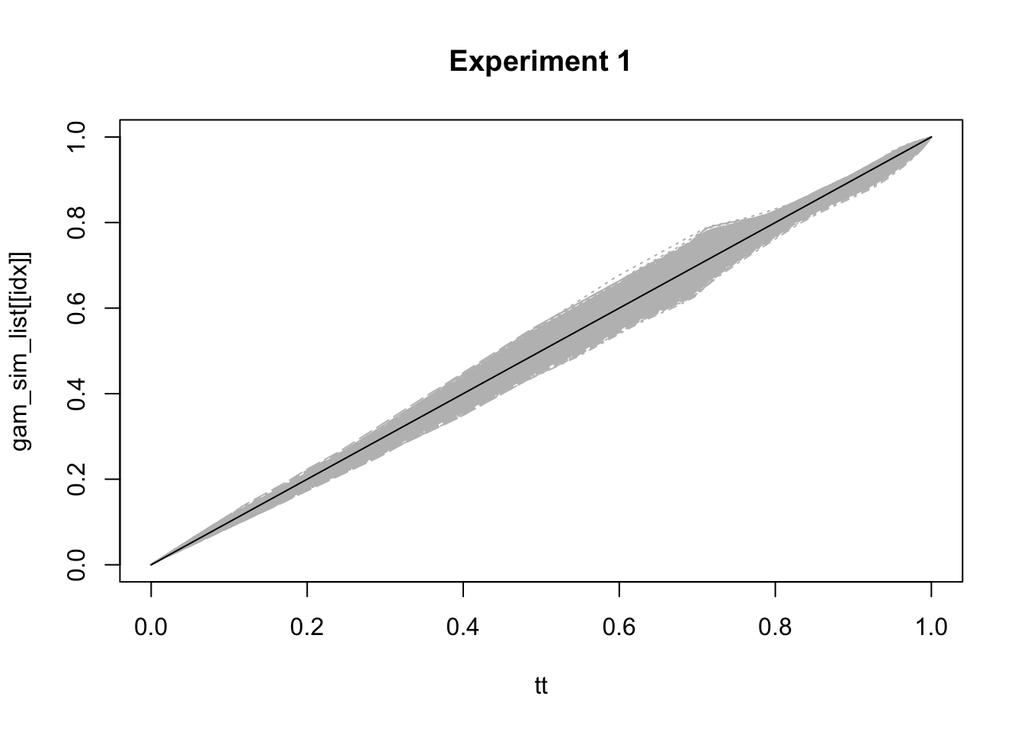

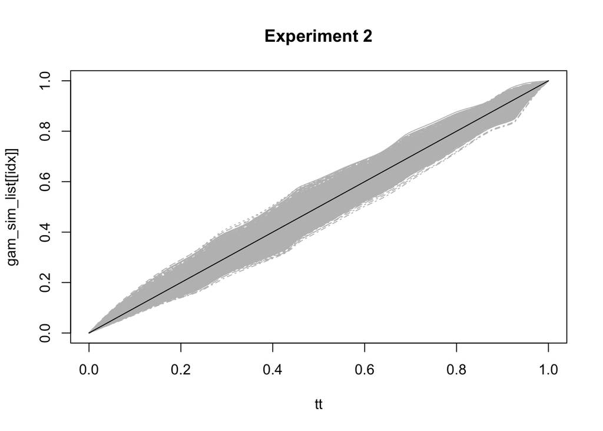

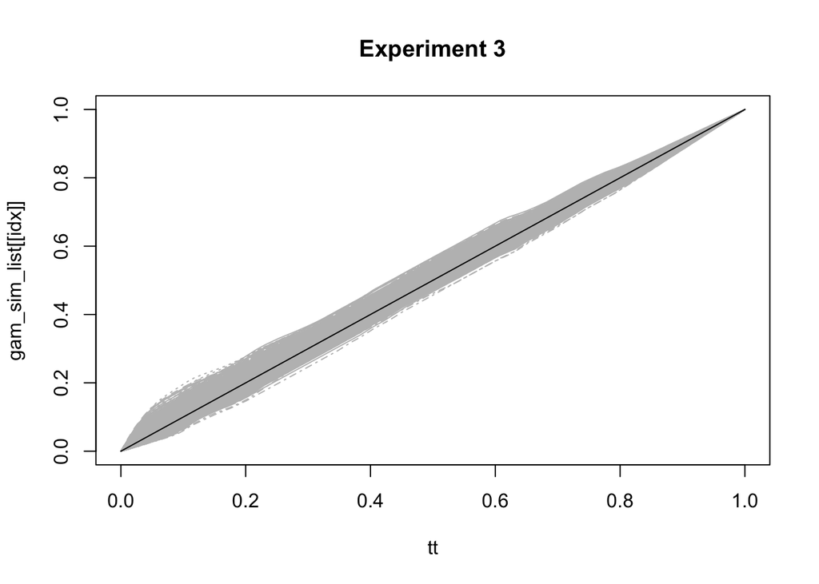

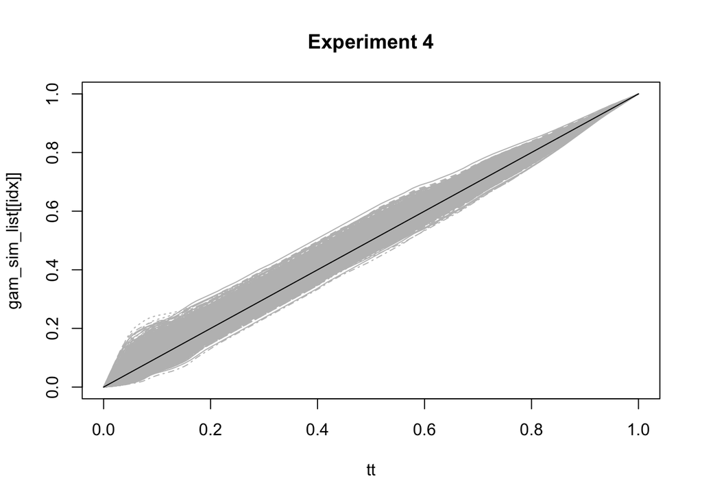

```r
for (idx in exps){
  matplot(tt, gam_sim_list[[idx]], type = "l", col = "gray", main=sprintf("Experiment %d",idx))
  lines(tt, gam_obs_list[[idx]], col = "black")
  legend(
    x = 0,
    y = 8,
    legend = c("simulation", "experiment"),
    col = c("gray", "black"),
    lty = 1
  )
}
```

and the corresponding shooting vectors

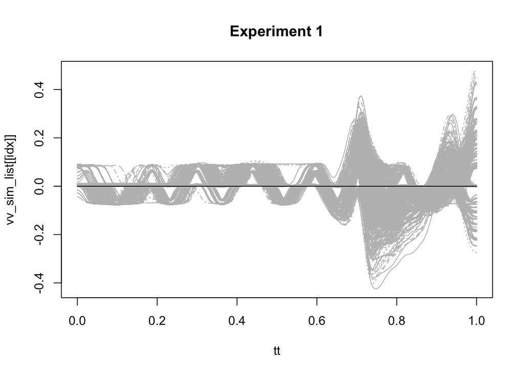

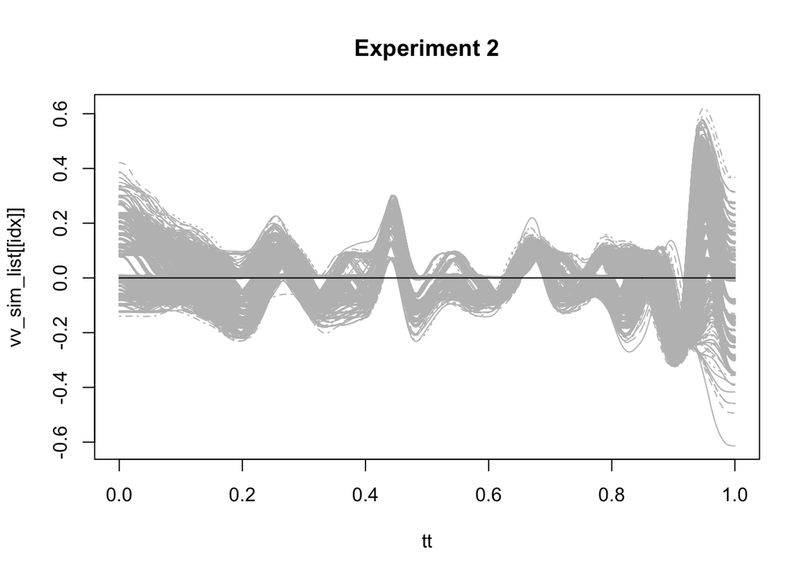

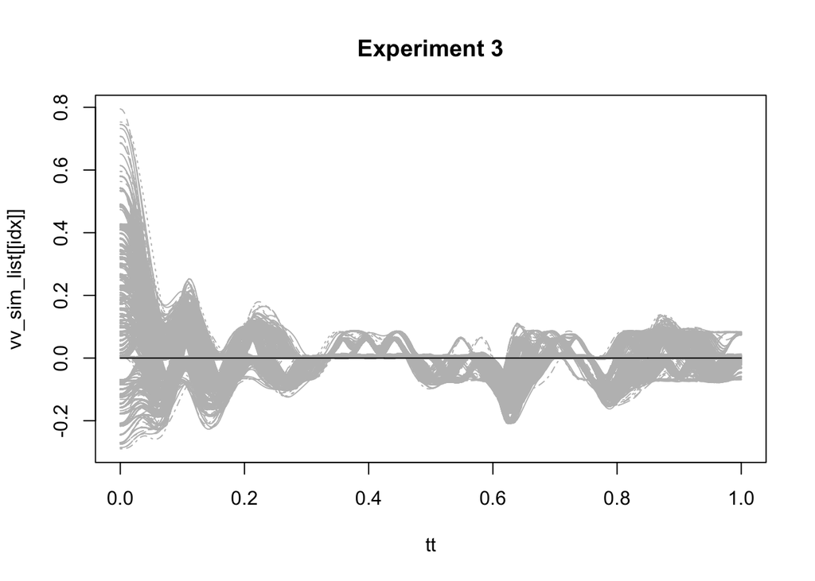

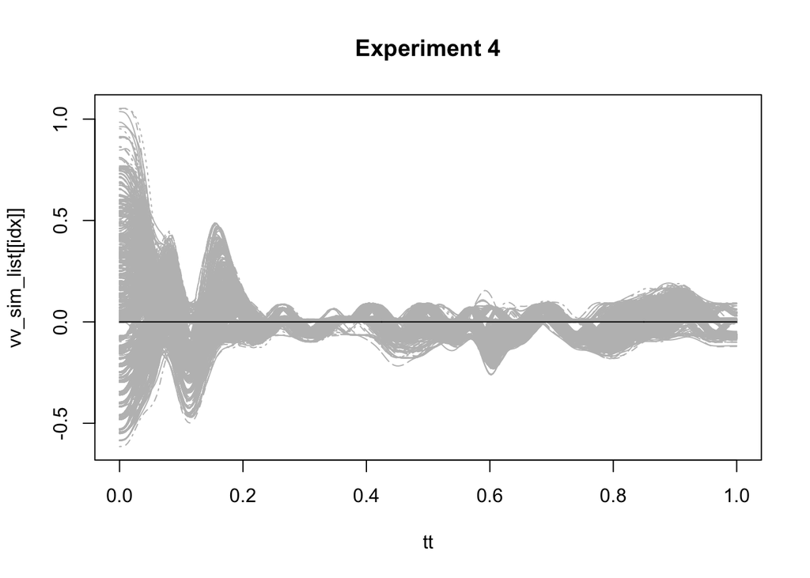

```r
for (idx in exps){
  matplot(tt, vv_sim_list[[idx]], type = "l", col = "gray", main=sprintf("Experiment %d",idx))
  lines(tt, vv_obs_list[[idx]], col = "black")
  legend(
    x = 0,
    y = 8,
    legend = c("simulation", "experiment"),
    col = c("gray", "black"),
    lty = 1
  )
}
```

# Surrogate Model Fitting

Next, we will fit the BASS surrogate to the computer model and evaluate its performance. We use the `mvBayes` package due to its ability to introspect surrogates and their performance.

The choice of `nBasis` here is made from exploratory data analysis. It can also be chosen based on the percentage of variance explained from the functional principal component analysis (fPCA) decomposition. The parameter in `mvBayes` do perform this is `propVarExplained`.

```r
emu_ftilde = list()
for (idx in 1:nexp){
  emu_ftilde[[idx]] = mvBayes(
  bass,
  sim_variables,
  t(ftilde_sim_list[[idx]]),
  idxSamplesArg="mcmc.use",
  nCores=parallel::detectCores(logical = TRUE),
  samplesExtract = function(bass_out) list(
    residSD = sqrt(bass_out$s2)),
  nBasis=7
  )
}

emu_vv = list()
for (idx in 1:nexp) {
  emu_vv[[idx]] = mvBayes(
    bass,
    sim_variables,
    t(vv_sim_list[[idx]]),
    idxSamplesArg="mcmc.use",
    nCores=parallel::detectCores(logical = TRUE),
    samplesExtract = function(bass_out) list(
      residSD = sqrt(bass_out$s2)),
    nBasis=14
    )
}
```

We can examine the fit of the surrogate model by looking at `mvBayes` diagnostic plots. We want to examine the MSE and if it is reasonable as well as the $R^2$ value to make sure its high enough. Also we can use the lower right panel to see how much explained variance is contained in the 7 principal components.

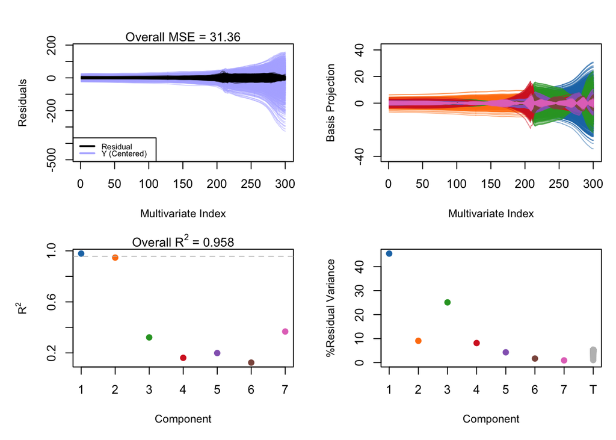

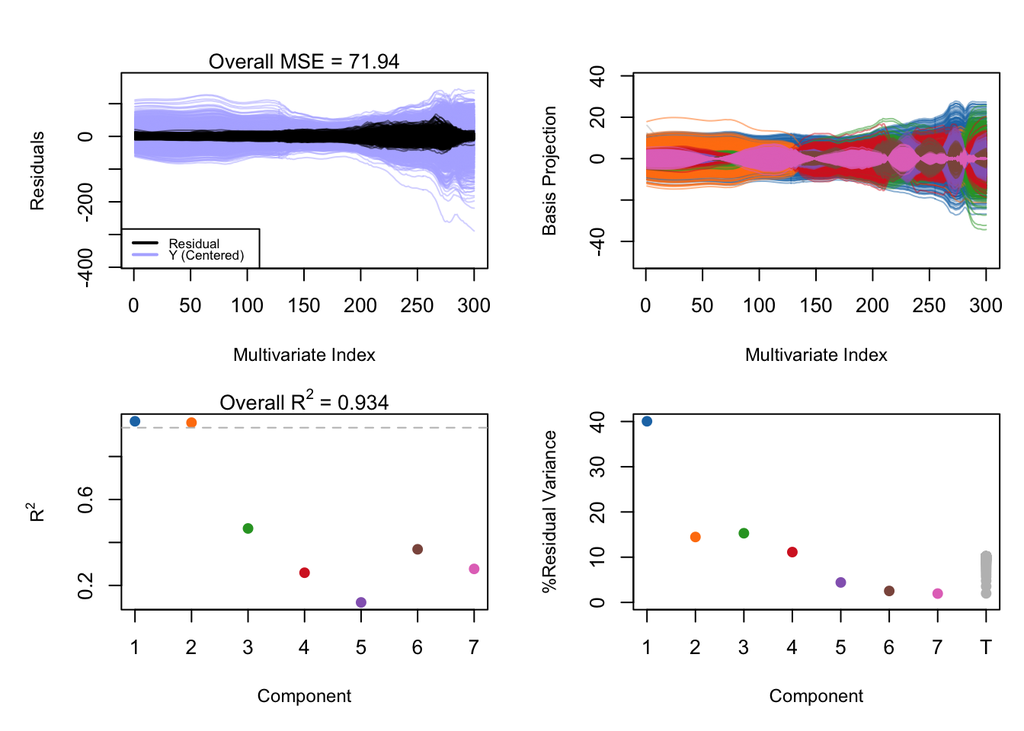

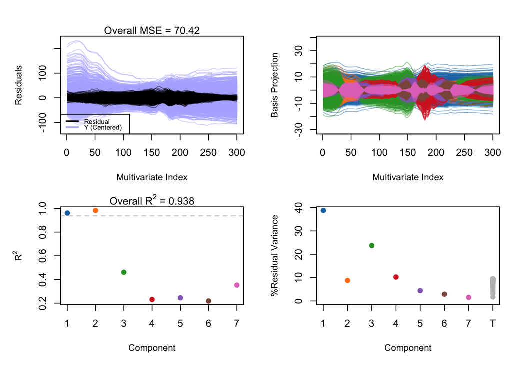

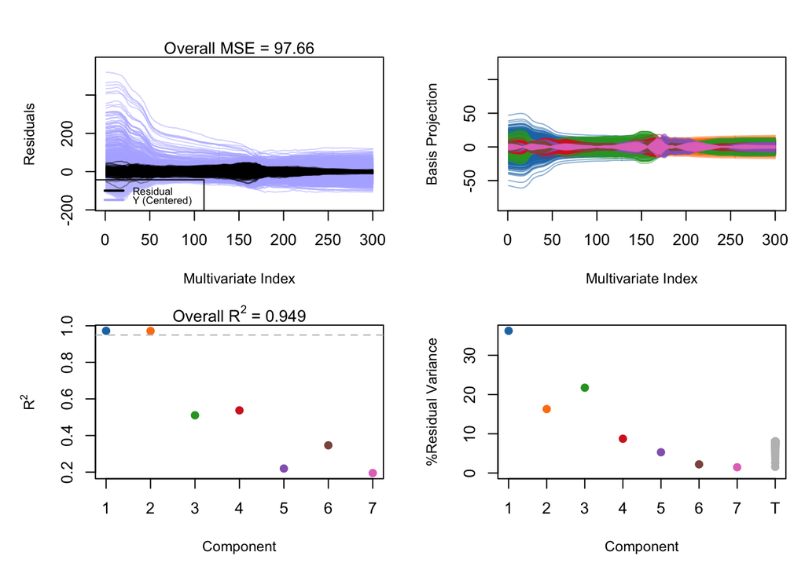

```r
for (idx in 1:nexp) {
  plot(emu_ftilde[[idx]])
}
```

We can also examine the fPCA decomposition to explore it more further if needed. We see that 7 components contain 99% of the explained variance

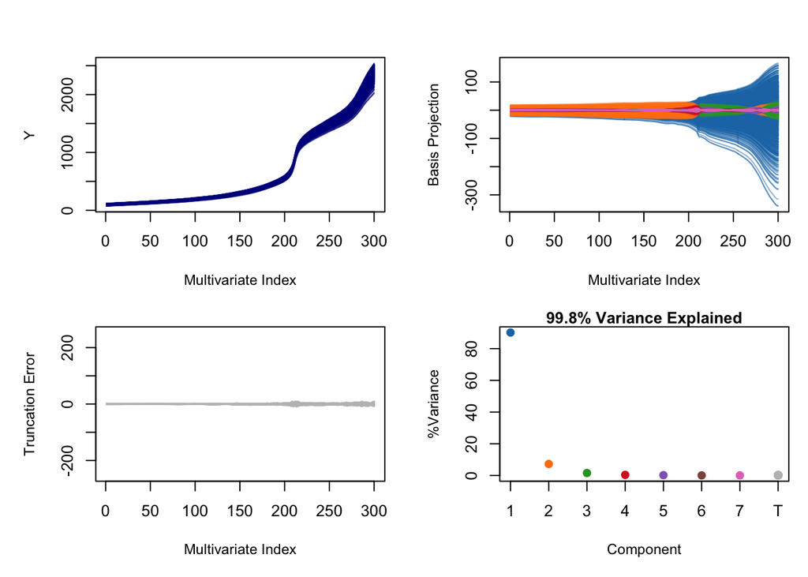

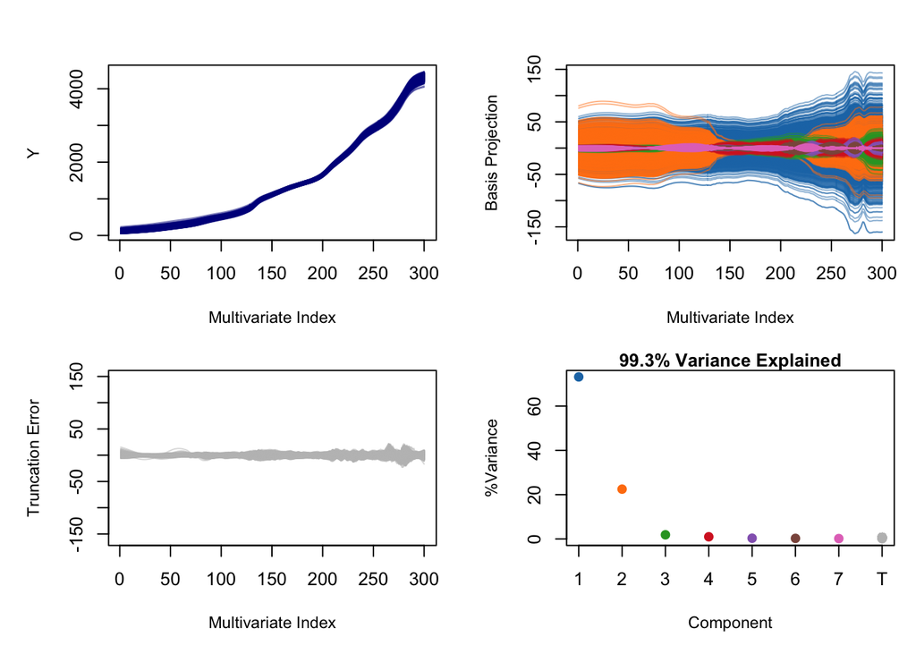

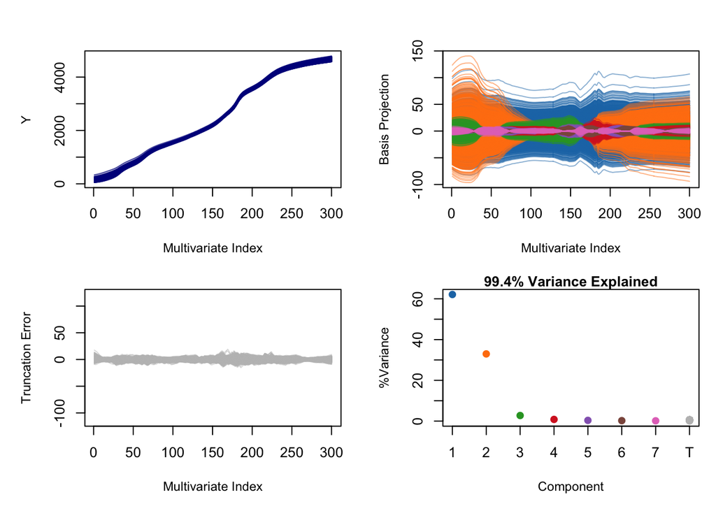

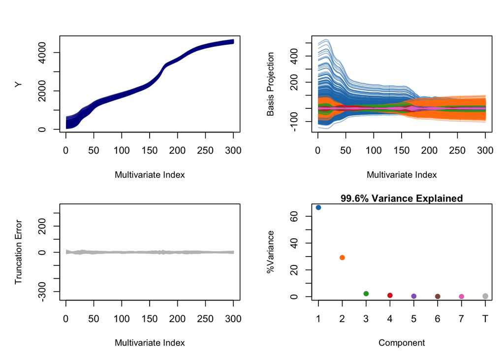

```r
for (idx in 1:nexp) {
  plot(emu_ftilde[[idx]]$basisInfo)
}
```

Lets evaluate the shooting vector emulator

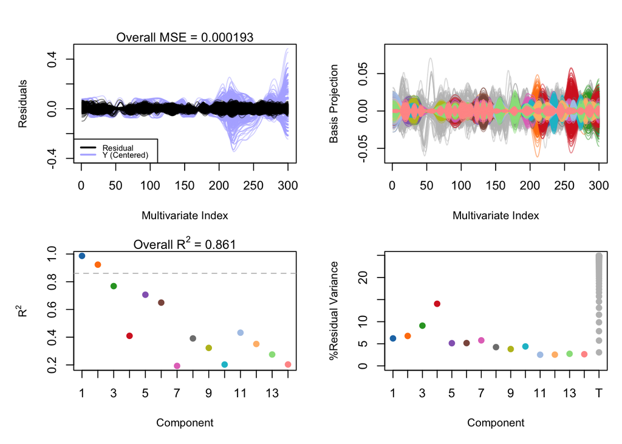

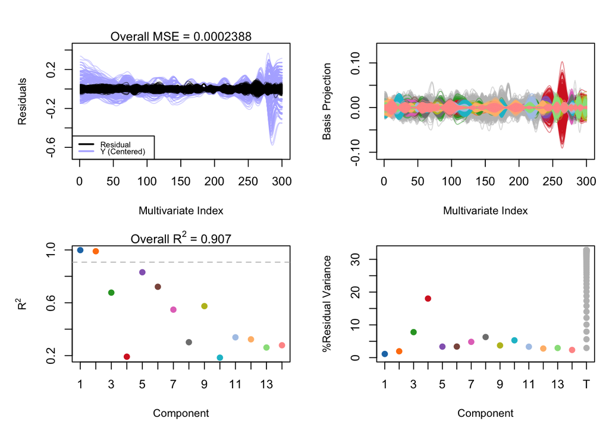

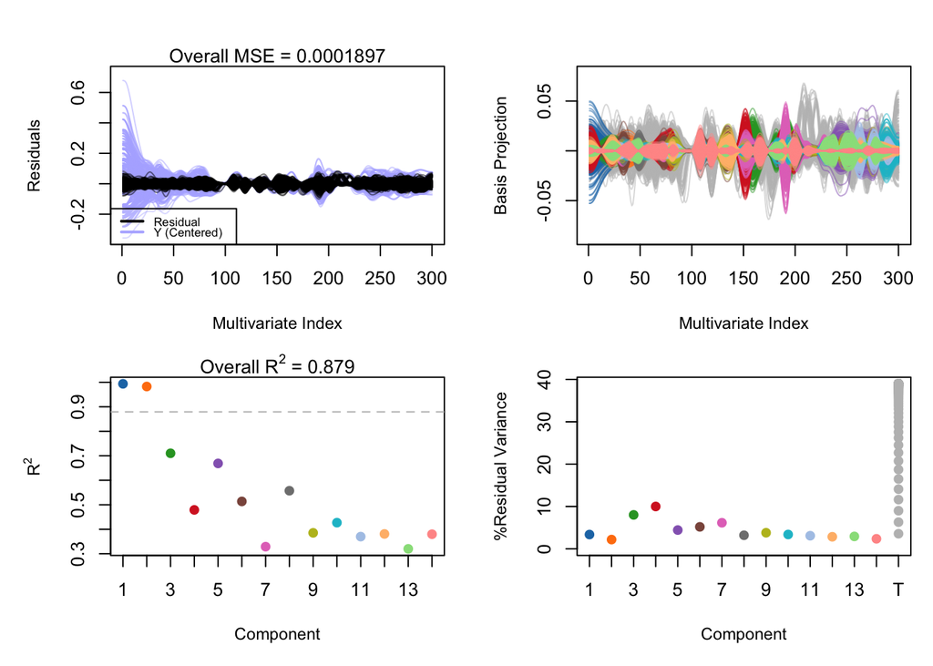

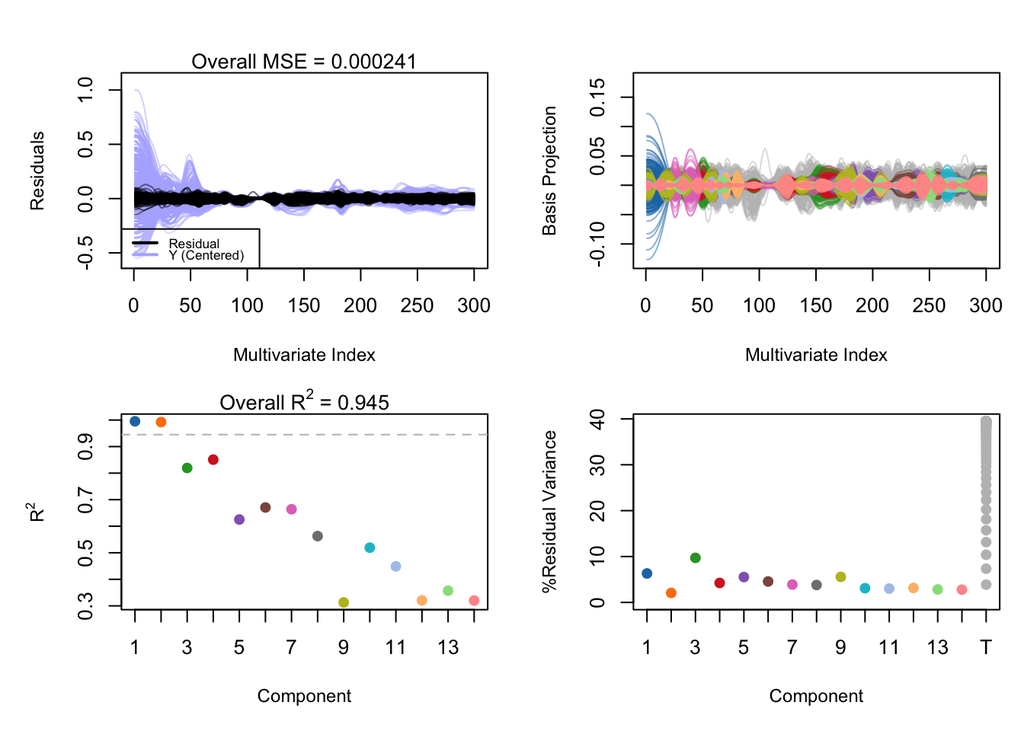

```r
for (idx in 1:nexp) {
  plot(emu_vv[[idx]])
}
```

# Bayesian Model Calibration

We will now set up `impala` to perform the calibration. First we need to setup the parameter names and bounds on the parameters. `impala` sets uniform priors on the parameters based on their bounds.

```r
input_names = c('rho0','B0','BP0','Y0','A')
Ni = length(input_names)
shared_vars = c('_floort_','_sampt_','dt','ucon','ulin')
param_names = c(input_names, shared_vars)

for (i in 1:nexp){
  input_names = c(input_names, c(sprintf("_floort_%d",i), sprintf("_sampt_%d",i), sprintf("dt_%d",i), sprintf("ucon_%d",i), sprintf("ulin_%d",i)))
}

sim_variables1 = matrix(0, nrow(sim_variables), length(input_names))
for (i in 1:Ni){
  sim_variables1[,i] = as.numeric(unlist(sim_variables[,input_names[i]]))
}
cnt = Ni+1
for (i in 1:nexp){
  for (j in 1:length(shared_vars)){
    sim_variables1[,cnt] = as.numeric(unlist(sim_variables[,shared_vars[j]]))
    cnt = cnt + 1
  }
}
p = ncol(sim_variables1)

bounds = list()
for (i in 1:p){
  bounds[[input_names[i]]] = c(min(sim_variables1[,i]), max(sim_variables1[,i]))
}
```

```r
setup = CalibSetup(bounds, cf_bounds)

for (j in 1:nexp){
  indexes = 1:Ni
  indexes = c(indexes, c(Ni + (j-1)*5+1, Ni + (j-1) * 5 + 2, Ni + (j-1) * 5 + 3, Ni + (j-1) * 5 + 4, Ni + (j-1) * 5 + 5))

  input_names1 = c()
  for (i in indexes){
    input_names1 = c(input_names1, input_names[i])
  }

  model_ftilde = ModelmvBayes(emu_ftilde[[j]], input_names1)
  model_vv = ModelmvBayes(emu_vv[[j]], input_names1)

  setup = addVecExperiments(setup, t(ftilde_obs_list[[j]]), model_ftilde, 0.001, 20, rep(1, M))
  setup = addVecExperiments(setup, t(vv_obs_list[[j]]), model_vv, 0.1, 20, rep(1, M))

}
setup = setTemperatureLadder(setup, 1.05 ^ (0:19))
setup = setMCMC(setup, 8000, 4000, 1, 10)
out_cal = calibPool(setup)
```

```r
uu = seq(6000, 8000, 2)

theta = tran_unif(out_cal$theta[uu, 1, ], setup$bounds_mat, names(setup$bounds))

time_new = seq(0, 1, length.out = M)

cnt = 1
ftilde_pred_obs = vector(mode = "list", length = setup$nexp)
gam_pred_obs = vector(mode = "list", length = setup$nexp)
vv_pred_obs = vector(mode = "list", length = setup$nexp)
median_pred = matrix(0, M, nexp)
gammedian_pred = matrix(0, M, nexp)
ftildemedian_pred = matrix(0, M, nexp)
for (idx in 1:nexp) {
  time_new = seq(0, 1, length.out = M)

  ftilde_pred_obs[[idx]] = evalm(setup$models[[cnt]], theta)
  vv_pred_obs[[idx]] = evalm(setup$models[[cnt + 1]], theta)
  cnt = cnt + 2
  gam_pred_obs[[idx]] = v_to_gam(t(vv_pred_obs[[idx]]))
}
```

Now we will look at the likelihood and chains to make sure the MCMC chains are stable and have converged.

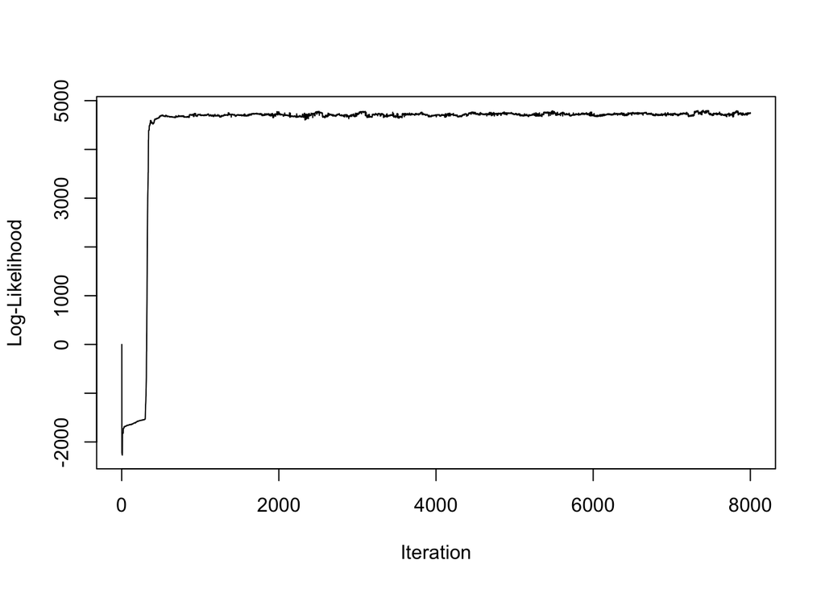

```r
plot(out_cal$llik, type="l", ylab="Log-Likelihood", xlab="Iteration")
```

Next we will look at convergence diagnostics of ESS and $\hat{R}$

```r
samps_coda = list()
for (ii in 1:20){
  samps_coda[[ii]] = mcmc(out_cal$theta[uu,ii,])
}
samps_coda_all = mcmc.list(samps_coda)
effectiveSize(samps_coda_all)
```

```
##       var1       var2       var3       var4       var5       var6       var7
##  114.42121  136.46736  496.59242  436.92099  247.23682  783.65886  223.52031
##       var8       var9      var10      var11      var12      var13      var14
##  456.64513  486.87160   96.32362 1200.42534  616.58197  376.14808  754.17525
##      var15      var16      var17      var18      var19      var20      var21
##  514.36627  500.95362  161.37669  257.20709  559.62055  226.75442  631.07249
##      var22      var23      var24      var25
##  929.34042  252.40860  523.08577  348.64876
```

```r
gelman.diag(samps_coda_all)
```

```
## Potential scale reduction factors:
##
##       Point est. Upper C.I.
##  [1,]      1.002      1.004
##  [2,]      1.000      1.001
##  [3,]      1.002      1.005
##  [4,]      0.999      0.999
##  [5,]      1.006      1.009
##  [6,]      1.000      1.000
##  [7,]      0.999      0.999
##  [8,]      1.000      1.001
##  [9,]      1.000      1.000
## [10,]      0.999      0.999
## [11,]      1.004      1.006
## [12,]      1.001      1.002
```

[output cut: 17 more lines]

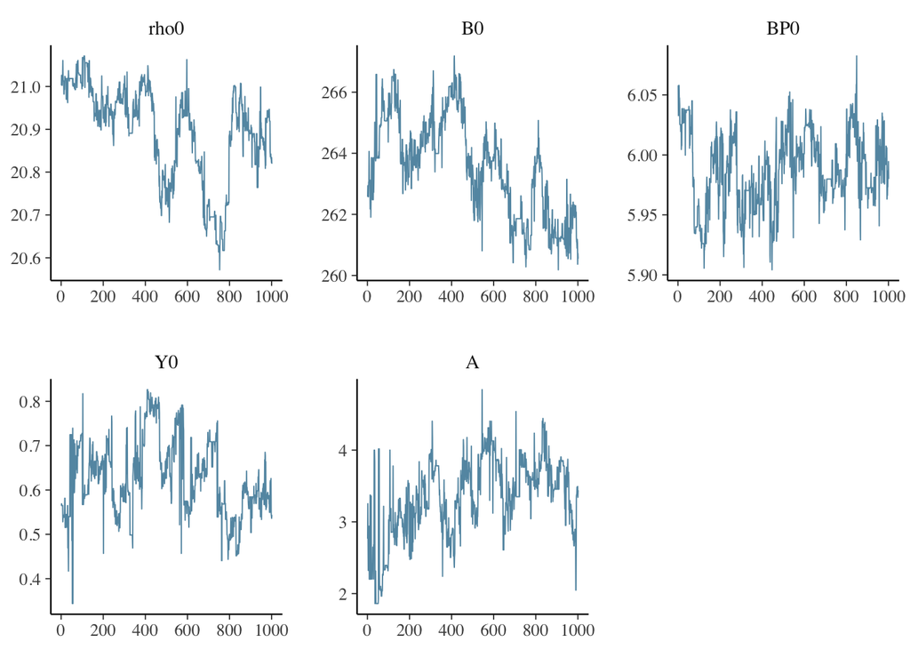

```r
samps = data.frame(theta[c(1,2,3,4,5)])
mcmc_trace(samps)
```

Examine the pair plot of the parameters. The diagonal contains the posterior distributions of the parameters. The off diagonal is the dependence.

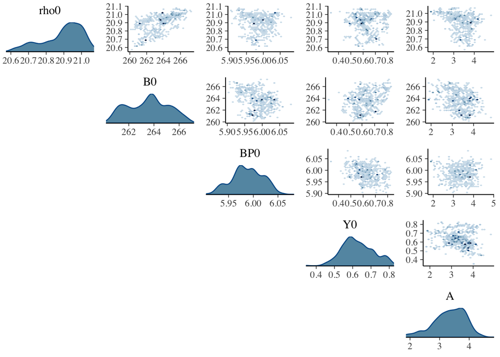

```r
p = mcmc_pairs(samps, off_diag_fun="hex", diag_fun = "dens")
p
```

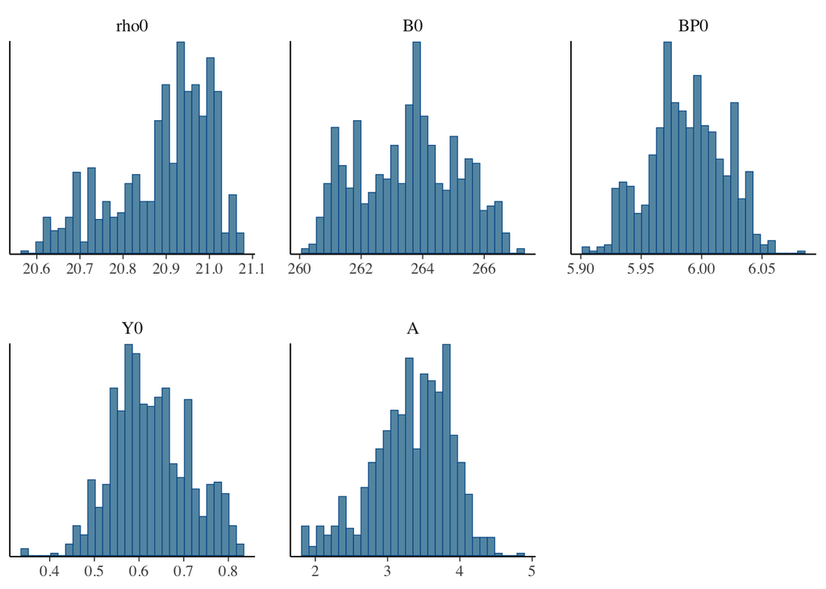

```r
mcmc_hist(samps)
```